# **Obesity risk**

#### **By Mohamed Jamyl**

http://linkedin.com/in/mohamed-jamyl

https://www.kaggle.com/mohamedjamyl

https://github.com/Mohamed-Jamyl

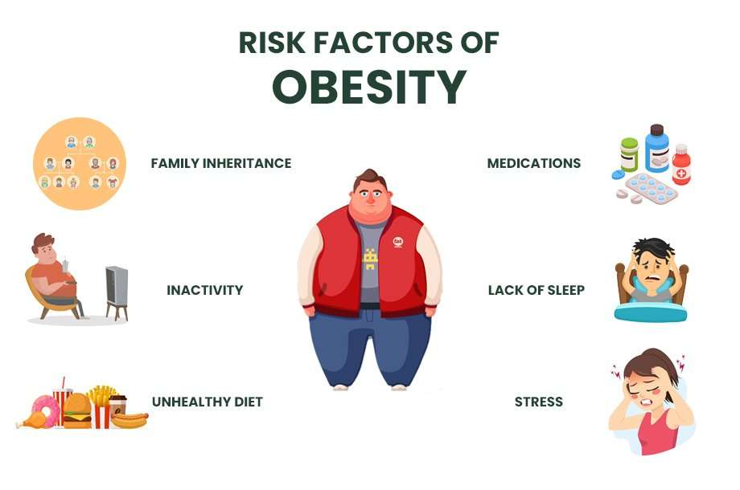

```python
from IPython.display import Image
Image(filename='obe.jpg')
```

## **Import Libraries**

```python
from pandas import read_csv, concat
from matplotlib.pyplot import show, tight_layout, subplots
from matplotlib.pyplot import figure, title, xlabel, ylabel, grid, tight_layout
from seaborn import kdeplot, heatmap, boxplot, regplot, countplot, histplot

from sklearn.model_selection import train_test_split
from sklearn.neighbors import KNeighborsClassifier
from sklearn.linear_model import LogisticRegression
from sklearn.svm import SVC
from sklearn.neighbors import KNeighborsClassifier
from sklearn.tree import DecisionTreeClassifier
from sklearn.ensemble import RandomForestClassifier
from sklearn.naive_bayes import GaussianNB

from sklearn.preprocessing import LabelEncoder,StandardScaler

from sklearn.metrics import classification_report

from pickle import dump

import warnings
warnings.filterwarnings("ignore", category=DeprecationWarning)
```

## **Exploratory Data Analysis (EDA)**

### **Initial Data Understanding**

- **Data loading and Inspection**
- **Data Types**
- **Missing Values**
- **Duplicates**

```python
train_df= read_csv('train_obesity.csv')
```

```python
train_df.head()
```

|  | id | Gender | Age | Height | Weight | family_history_with_overweight | FAVC | FCVC | NCP | CAEC | SMOKE | CH2O | SCC | FAF | TUE | CALC | MTRANS | NObeyesdad |
| --- | --- | --- | --- | --- | --- | --- | --- | --- | --- | --- | --- | --- | --- | --- | --- | --- | --- | --- |
| 0 | 0 | Male | 24.443011 | 1.699998 | 81.669950 | yes | yes | 2.000000 | 2.983297 | Sometimes | no | 2.763573 | no | 0.000000 | 0.976473 | Sometimes | Public_Transportation | Overweight_Level_II |
| 1 | 1 | Female | 18.000000 | 1.560000 | 57.000000 | yes | yes | 2.000000 | 3.000000 | Frequently | no | 2.000000 | no | 1.000000 | 1.000000 | no | Automobile | Normal_Weight |
| 2 | 2 | Female | 18.000000 | 1.711460 | 50.165754 | yes | yes | 1.880534 | 1.411685 | Sometimes | no | 1.910378 | no | 0.866045 | 1.673584 | no | Public_Transportation | Insufficient_Weight |
| 3 | 3 | Female | 20.952737 | 1.710730 | 131.274851 | yes | yes | 3.000000 | 3.000000 | Sometimes | no | 1.674061 | no | 1.467863 | 0.780199 | Sometimes | Public_Transportation | Obesity_Type_III |
| 4 | 4 | Male | 31.641081 | 1.914186 | 93.798055 | yes | yes | 2.679664 | 1.971472 | Sometimes | no | 1.979848 | no | 1.967973 | 0.931721 | Sometimes | Public_Transportation | Overweight_Level_II |

```python
train_df.sample(10)
```

|  | id | Gender | Age | Height | Weight | family_history_with_overweight | FAVC | FCVC | NCP | CAEC | SMOKE | CH2O | SCC | FAF | TUE | CALC | MTRANS | NObeyesdad |
| --- | --- | --- | --- | --- | --- | --- | --- | --- | --- | --- | --- | --- | --- | --- | --- | --- | --- | --- |
| 8079 | 8079 | Male | 26.680376 | 1.758733 | 120.794535 | yes | yes | 2.967300 | 3.000000 | Sometimes | no | 2.868167 | no | 0.943266 | 0.619235 | Sometimes | Public_Transportation | Obesity_Type_II |
| 7756 | 7756 | Male | 55.000000 | 1.700000 | 80.000000 | yes | yes | 3.000000 | 3.000000 | Frequently | no | 2.000000 | no | 0.000000 | 0.000000 | Sometimes | Automobile | Overweight_Level_II |
| 10097 | 10097 | Male | 23.000000 | 1.740000 | 68.000000 | no | yes | 2.000000 | 3.000000 | Frequently | no | 2.000000 | no | 1.000000 | 1.000000 | no | Public_Transportation | Normal_Weight |
| 17581 | 17581 | Female | 37.441044 | 1.633794 | 80.000000 | yes | yes | 2.000000 | 1.000610 | Sometimes | no | 1.310074 | no | 0.002030 | 0.000000 | Sometimes | Automobile | Obesity_Type_I |
| 13941 | 13941 | Female | 25.986185 | 1.626580 | 109.980145 | yes | yes | 3.000000 | 3.000000 | Sometimes | no | 2.550570 | no | 0.015860 | 0.484165 | Sometimes | Public_Transportation | Obesity_Type_III |
| 5739 | 5739 | Male | 30.575349 | 1.860292 | 120.399758 | yes | yes | 2.766612 | 3.000000 | Sometimes | no | 2.838893 | no | 1.352663 | 0.000000 | Sometimes | Automobile | Obesity_Type_II |
| 12715 | 12715 | Male | 24.444846 | 1.747739 | 84.653029 | yes | yes | 2.000000 | 2.658837 | Sometimes | no | 2.000000 | no | 0.000000 | 0.839862 | Sometimes | Public_Transportation | Overweight_Level_II |
| 18505 | 18505 | Male | 30.722801 | 1.767186 | 120.901591 | yes | yes | 2.919526 | 3.000000 | Sometimes | no | 2.089983 | no | 1.193486 | 0.002600 | Sometimes | Automobile | Obesity_Type_II |
| 17439 | 17439 | Male | 34.000000 | 1.750000 | 75.000000 | yes | yes | 3.000000 | 3.000000 | Sometimes | no | 2.000000 | no | 2.000000 | 0.000000 | Sometimes | Automobile | Normal_Weight |
| 16547 | 16547 | Female | 26.000000 | 1.624134 | 110.803117 | yes | yes | 3.000000 | 3.000000 | Sometimes | no | 2.653563 | no | 0.000000 | 0.269577 | Sometimes | Public_Transportation | Obesity_Type_III |

```python
train_df.tail()
```

|  | id | Gender | Age | Height | Weight | family_history_with_overweight | FAVC | FCVC | NCP | CAEC | SMOKE | CH2O | SCC | FAF | TUE | CALC | MTRANS | NObeyesdad |
| --- | --- | --- | --- | --- | --- | --- | --- | --- | --- | --- | --- | --- | --- | --- | --- | --- | --- | --- |
| 20753 | 20753 | Male | 25.137087 | 1.766626 | 114.187096 | yes | yes | 2.919584 | 3.000000 | Sometimes | no | 2.151809 | no | 1.330519 | 0.196680 | Sometimes | Public_Transportation | Obesity_Type_II |
| 20754 | 20754 | Male | 18.000000 | 1.710000 | 50.000000 | no | yes | 3.000000 | 4.000000 | Frequently | no | 1.000000 | no | 2.000000 | 1.000000 | Sometimes | Public_Transportation | Insufficient_Weight |
| 20755 | 20755 | Male | 20.101026 | 1.819557 | 105.580491 | yes | yes | 2.407817 | 3.000000 | Sometimes | no | 2.000000 | no | 1.158040 | 1.198439 | no | Public_Transportation | Obesity_Type_II |
| 20756 | 20756 | Male | 33.852953 | 1.700000 | 83.520113 | yes | yes | 2.671238 | 1.971472 | Sometimes | no | 2.144838 | no | 0.000000 | 0.973834 | no | Automobile | Overweight_Level_II |
| 20757 | 20757 | Male | 26.680376 | 1.816547 | 118.134898 | yes | yes | 3.000000 | 3.000000 | Sometimes | no | 2.003563 | no | 0.684487 | 0.713823 | Sometimes | Public_Transportation | Obesity_Type_II |

```python
train_df.shape
```

```
(20758, 18)
```

```python
train_df.columns
```

```
Index(['id', 'Gender', 'Age', 'Height', 'Weight',
       'family_history_with_overweight', 'FAVC', 'FCVC', 'NCP', 'CAEC',
       'SMOKE', 'CH2O', 'SCC', 'FAF', 'TUE', 'CALC', 'MTRANS', 'NObeyesdad'],
      dtype='object')
```

```python
# Changing the names of some columns

train_df.rename(columns={'FAVC': 'Frequent consumption of high-caloric food',
                         'family_history_with_overweight':'Family history with overweight',
                         'FCVC': 'Frequency of vegetable consumption',
                         'NCP':'Number of main meals the person eats per day',
                         'CAEC':'Consumption of food between meals',
                         'CH2O':'Daily water consumption',
                         'SCC':'Whether the person takes calorie supplements',
                         'FAF':'Physical activity frequency',
                         'TUE':'Time spent using technology',
                         'CALC':'Alcohol consumption',
                         'MTRANS':'Means of transportation used',
                         'NObeyesdad':'Obesity level class' } ,inplace=True)
```

```python
train_df.columns
```

```
Index(['id', 'Gender', 'Age', 'Height', 'Weight',
       'Family history with overweight',
       'Frequent consumption of high-caloric food',
       'Frequency of vegetable consumption',
       'Number of main meals the person eats per day',
       'Consumption of food between meals', 'SMOKE', 'Daily water consumption',
       'Whether the person takes calorie supplements',
       'Physical activity frequency', 'Time spent using technology',
       'Alcohol consumption', 'Means of transportation used',
       'Obesity level class'],
      dtype='object')
```

```python
train_df.info()
```

```
<class 'pandas.core.frame.DataFrame'>
RangeIndex: 20758 entries, 0 to 20757
Data columns (total 18 columns):
 #   Column                                        Non-Null Count  Dtype
---  ------                                        --------------  -----
 0   id                                            20758 non-null  int64
 1   Gender                                        20758 non-null  object
 2   Age                                           20758 non-null  float64
 3   Height                                        20758 non-null  float64
 4   Weight                                        20758 non-null  float64
 5   Family history with overweight                20758 non-null  object
 6   Frequent consumption of high-caloric food     20758 non-null  object
 7   Frequency of vegetable consumption            20758 non-null  float64
 8   Number of main meals the person eats per day  20758 non-null  float64
 9   Consumption of food between meals             20758 non-null  object
 10  SMOKE                                         20758 non-null  object
 11  Daily water consumption                       20758 non-null  float64
 12  Whether the person takes calorie supplements  20758 non-null  object
 13  Physical activity frequency                   20758 non-null  float64
 14  Time spent using technology                   20758 non-null  float64
 15  Alcohol consumption                           20758 non-null  object
 16  Means of transportation used                  20758 non-null  object
 17  Obesity level class                           20758 non-null  object
dtypes: float64(8), int64(1), object(9)
memory usage: 2.9+ MB
```

```python
train_df.isnull().sum()
```

```
id                                              0
Gender                                          0
Age                                             0
Height                                          0
Weight                                          0
Family history with overweight                  0
Frequent consumption of high-caloric food       0
Frequency of vegetable consumption              0
Number of main meals the person eats per day    0
Consumption of food between meals               0
SMOKE                                           0
Daily water consumption                         0
Whether the person takes calorie supplements    0
Physical activity frequency                     0
Time spent using technology                     0
Alcohol consumption                             0
Means of transportation used                    0
Obesity level class                             0
dtype: int64
```

```python
train_df.duplicated().sum()
```

```
0
```

```python
train_df = train_df.drop('id',axis=1)
```

### **Basic Statistical Overview**

- Summary Statistical : **describe()**

```python
train_df.describe().T
```

|  | count | mean | std | min | 25% | 50% | 75% | max |
| --- | --- | --- | --- | --- | --- | --- | --- | --- |
| Age | 20758.0 | 23.841804 | 5.688072 | 14.00 | 20.000000 | 22.815416 | 26.000000 | 61.000000 |
| Height | 20758.0 | 1.700245 | 0.087312 | 1.45 | 1.631856 | 1.700000 | 1.762887 | 1.975663 |
| Weight | 20758.0 | 87.887768 | 26.379443 | 39.00 | 66.000000 | 84.064875 | 111.600553 | 165.057269 |
| Frequency of vegetable consumption | 20758.0 | 2.445908 | 0.533218 | 1.00 | 2.000000 | 2.393837 | 3.000000 | 3.000000 |
| Number of main meals the person eats per day | 20758.0 | 2.761332 | 0.705375 | 1.00 | 3.000000 | 3.000000 | 3.000000 | 4.000000 |
| Daily water consumption | 20758.0 | 2.029418 | 0.608467 | 1.00 | 1.792022 | 2.000000 | 2.549617 | 3.000000 |
| Physical activity frequency | 20758.0 | 0.981747 | 0.838302 | 0.00 | 0.008013 | 1.000000 | 1.587406 | 3.000000 |
| Time spent using technology | 20758.0 | 0.616756 | 0.602113 | 0.00 | 0.000000 | 0.573887 | 1.000000 | 2.000000 |

```python
train_df.select_dtypes(include='object').describe()
```

|  | Gender | Family history with overweight | Frequent consumption of high-caloric food | Consumption of food between meals | SMOKE | Whether the person takes calorie supplements | Alcohol consumption | Means of transportation used | Obesity level class |
| --- | --- | --- | --- | --- | --- | --- | --- | --- | --- |
| count | 20758 | 20758 | 20758 | 20758 | 20758 | 20758 | 20758 | 20758 | 20758 |
| unique | 2 | 2 | 2 | 4 | 2 | 2 | 3 | 5 | 7 |
| top | Female | yes | yes | Sometimes | no | no | Sometimes | Public_Transportation | Obesity_Type_III |
| freq | 10422 | 17014 | 18982 | 17529 | 20513 | 20071 | 15066 | 16687 | 4046 |

- Summary Statistical : **value_counts()**

```python
train_df['Gender'].value_counts()
```

```
Gender
Female    10422
Male      10336
Name: count, dtype: int64
```

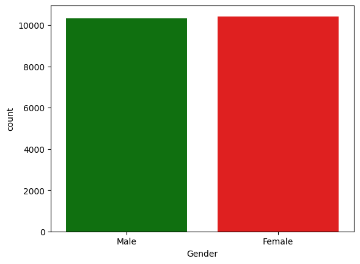

```python
countplot(x='Gender', data=train_df, palette=['green','red'])
xlabel('Gender')
show()
```

```python
train_df['Family history with overweight'].value_counts()
```

```
Family history with overweight
yes    17014
no      3744
Name: count, dtype: int64
```

```python
train_df['Frequent consumption of high-caloric food'].value_counts()
```

```
Frequent consumption of high-caloric food
yes    18982
no      1776
Name: count, dtype: int64
```

```python
train_df['Consumption of food between meals'].value_counts()
```

```
Consumption of food between meals
Sometimes     17529
Frequently     2472
Always          478
no              279
Name: count, dtype: int64
```

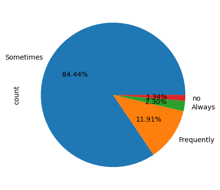

```python
train_df['Consumption of food between meals'].value_counts().plot.pie(autopct='%0.2f%%')
show()
```

##### **The percentage of Consumption of food between meals (sometimes) is very high (84.44 %) compared to the rest of the other percentages**

```python
train_df['SMOKE'].value_counts()
```

```
SMOKE
no     20513
yes      245
Name: count, dtype: int64
```

```python
train_df['Whether the person takes calorie supplements'].value_counts()
```

```
Whether the person takes calorie supplements
no     20071
yes      687
Name: count, dtype: int64
```

```python
train_df['Alcohol consumption'].value_counts()
```

```
Alcohol consumption
Sometimes     15066
no             5163
Frequently      529
Name: count, dtype: int64
```

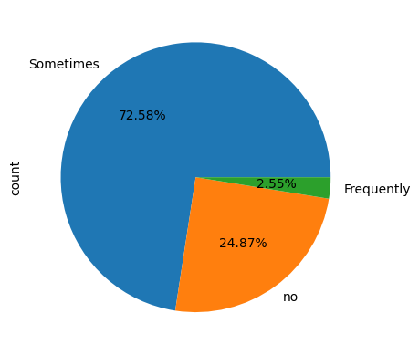

```python
train_df['Alcohol consumption'].value_counts().plot.pie(autopct='%0.2f%%')
show()
```

##### **The percentage of Alcohol consumption (sometimes) is very high (72.58 %) compared to percentages of the rest of the other percentages**

```python
train_df['Means of transportation used'].value_counts()
```

```
Means of transportation used
Public_Transportation    16687
Automobile                3534
Walking                    467
Motorbike                   38
Bike                        32
Name: count, dtype: int64
```

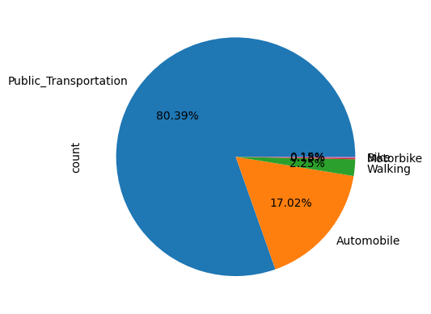

```python
train_df['Means of transportation used'].value_counts().plot.pie(autopct='%0.2f%%')
show()
```

##### **The percentage of using public transport is very hight (80.39 %) compared to percentages of the rest of the other percentages**

```python
train_df['Obesity level class'].value_counts()
```

```
Obesity level class
Obesity_Type_III       4046
Obesity_Type_II        3248
Normal_Weight          3082
Obesity_Type_I         2910
Insufficient_Weight    2523
Overweight_Level_II    2522
Overweight_Level_I     2427
Name: count, dtype: int64
```

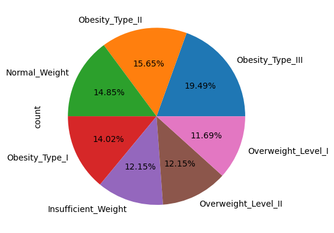

```python
train_df['Obesity level class'].value_counts().plot.pie(autopct='%0.2f%%')
show()
```

## **Distribution of Variables**

- **Numerical Features (KDE)**

```python
train_df.select_dtypes('number')
```

|  | Age | Height | Weight | Frequency of vegetable consumption | Number of main meals the person eats per day | Daily water consumption | Physical activity frequency | Time spent using technology |
| --- | --- | --- | --- | --- | --- | --- | --- | --- |
| 0 | 24.443011 | 1.699998 | 81.669950 | 2.000000 | 2.983297 | 2.763573 | 0.000000 | 0.976473 |
| 1 | 18.000000 | 1.560000 | 57.000000 | 2.000000 | 3.000000 | 2.000000 | 1.000000 | 1.000000 |
| 2 | 18.000000 | 1.711460 | 50.165754 | 1.880534 | 1.411685 | 1.910378 | 0.866045 | 1.673584 |
| 3 | 20.952737 | 1.710730 | 131.274851 | 3.000000 | 3.000000 | 1.674061 | 1.467863 | 0.780199 |
| 4 | 31.641081 | 1.914186 | 93.798055 | 2.679664 | 1.971472 | 1.979848 | 1.967973 | 0.931721 |
| ... | ... | ... | ... | ... | ... | ... | ... | ... |
| 20753 | 25.137087 | 1.766626 | 114.187096 | 2.919584 | 3.000000 | 2.151809 | 1.330519 | 0.196680 |
| 20754 | 18.000000 | 1.710000 | 50.000000 | 3.000000 | 4.000000 | 1.000000 | 2.000000 | 1.000000 |
| 20755 | 20.101026 | 1.819557 | 105.580491 | 2.407817 | 3.000000 | 2.000000 | 1.158040 | 1.198439 |
| 20756 | 33.852953 | 1.700000 | 83.520113 | 2.671238 | 1.971472 | 2.144838 | 0.000000 | 0.973834 |
| 20757 | 26.680376 | 1.816547 | 118.134898 | 3.000000 | 3.000000 | 2.003563 | 0.684487 | 0.713823 |

20758 rows × 8 columns

```python
# for	col	in train_df.select_dtypes('number').columns:
#     figure(figsize=(12,	4))
#     kdeplot(train_df[col], fill=True,	color='blue', alpha=0.6)
#     title(f'Kernel Density Estimate(KDE) - {col}',	fontsize=16)
#     xlabel(col,	fontsize=12)
#     ylabel('Density', fontsize=12)
#     grid(True, linestyle='--', alpha=0.7)
#     tight_layout()
#     show()
```

#### **The Distribution of Age**

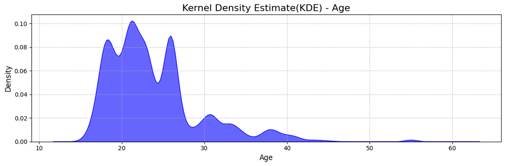

```python
figure(figsize=(12,	4))
kdeplot(train_df['Age'], fill=True,	color='blue', alpha=0.6)
title(f'Kernel Density Estimate(KDE) - Age',	fontsize=16)
xlabel('Age',	fontsize=12)
ylabel('Density', fontsize=12)
grid(True, linestyle='--', alpha=0.7)
tight_layout()
show()
```

##### **Tail Decline**: The right tail of the distribution gradually declines, suggesting a smaller number of individuals in the older age groups.

#### **The Distribution of Height**

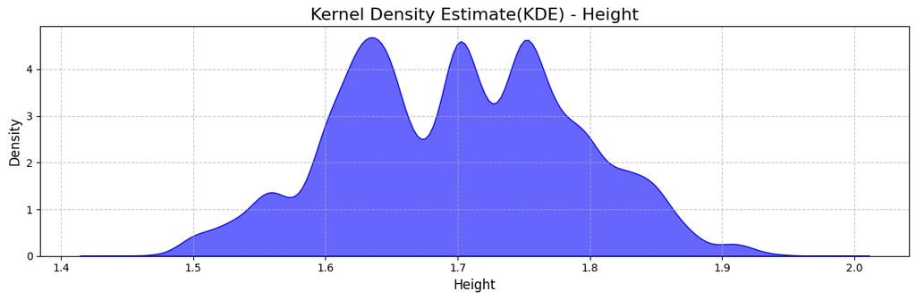

```python
figure(figsize=(12,	4))
kdeplot(train_df['Height'], fill=True,	color='blue', alpha=0.6)
title(f'Kernel Density Estimate(KDE) - Height',	fontsize=16)
xlabel('Height',	fontsize=12)
ylabel('Density', fontsize=12)
grid(True, linestyle='--', alpha=0.7)
tight_layout()
show()
```

##### **Multimodal Distribution**: Plot also shows multiple peaks, suggesting the presence of several groups with different height ranges that are more frequent in dataset.

##### **Dominant Height Ranges**: The most prominent peaks appear to be around heights of approximately 1.65 meters and 1.75 meters. This indicates that individuals with these heights are most common in data.

##### **Secondary Peak**: There's a smaller but noticeable peak around 1.55 meters, suggesting another, less frequent, group of individuals with this height.

##### **Height Range**: The distribution of height spans from roughly 1.4 meters to 2.0 meters, indicating the range of heights present in dataset.

##### **Lower Density at Extremes**: The density is considerably lower at the extreme ends of the height spectrum (very short or very tall individuals) compared to the central peaks

#### **The Distribution of Weight**

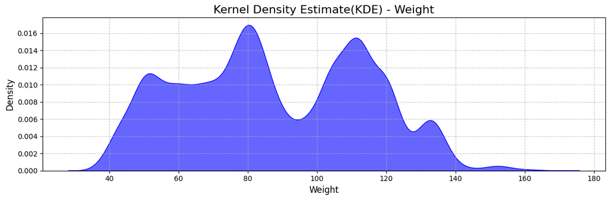

```python
figure(figsize=(12,	4))
kdeplot(train_df['Weight'], fill=True,	color='blue', alpha=0.6)
title(f'Kernel Density Estimate(KDE) - Weight',	fontsize=16)
xlabel('Weight',	fontsize=12)
ylabel('Density', fontsize=12)
grid(True, linestyle='--', alpha=0.7)
tight_layout()
show()
```

##### **Primary Weight Group**: The higher peak appears around a weight of approximately 80 kilograms. This suggests that a significant portion of your dataset consists of individuals weighing around this value.

##### **Secondary Weight Group**: The second, slightly lower peak is located around 115 kilograms. This indicates another substantial group of individuals with a higher average weight compared to the first group.

##### **Weight Range**: The distribution of weight spans from roughly 30 kilograms to 180 kilograms, showing the overall range of weights present in data.

##### **Lower Density in Between and at Extremes**: The density is notably lower between the two main peaks (around 90-100 kg) and also at the very low and very high ends of the weight spectrum. This implies fewer individuals in these weight ranges within dataset.

##### **Smaller Peaks**: There are also smaller bumps or minor peaks visible, for instance, around 55 kg and 140 kg, which might represent smaller subgroups within data.

#### **The Distribution of daily water consumption**

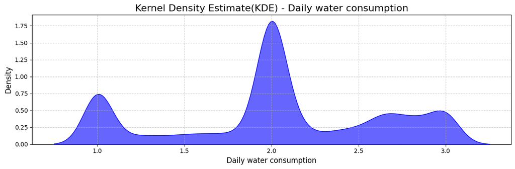

```python
figure(figsize=(12,	4))
kdeplot(train_df['Daily water consumption'], fill=True,	color='blue', alpha=0.6)
title(f'Kernel Density Estimate(KDE) - Daily water consumption',	fontsize=16)
xlabel('Daily water consumption',	fontsize=12)
ylabel('Density', fontsize=12)
grid(True, linestyle='--', alpha=0.7)
tight_layout()
show()
```

##### **Trimodal Distribution**: We can clearly observe three distinct peaks, suggesting three common levels of daily water consumption within dataset. This indicates the presence of at least three groups of individuals with different typical water intake habits.

##### **Primary Consumption Level**: The most prominent peak occurs around 2 liters of daily water consumption. This indicates that a significant portion of individuals in dataset tends to consume around this amount of water per day.

##### **Secondary Consumption Levels**: There are two other notable peaks. One, smaller than the primary peak, is located around 1 liter, suggesting another group with lower daily water intake. The third peak, also substantial, appears around 3 liters, indicating a group with higher daily water consumption.

##### **Range of Consumption**: The distribution spans from approximately 0.5 liters to 3.5 liters of daily water consumption, showing the overall range observed in data.

##### **Lower Density in Between**: The density is lower in the regions between these peaks, suggesting fewer individuals with daily water consumption levels between 1 and 2 liters, and between 2 and 3 liters.

#### **The Distribution of physical activity frequency**

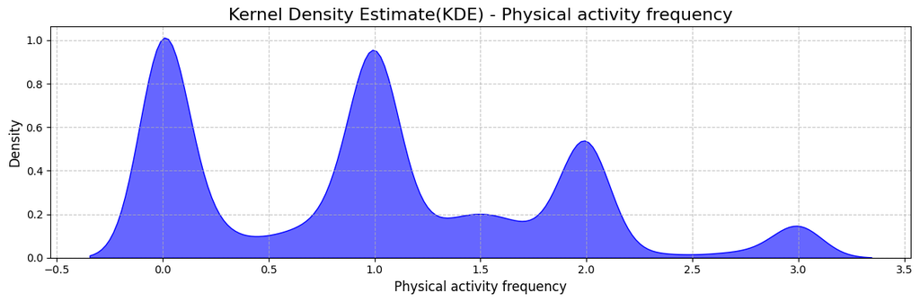

```python
figure(figsize=(12,	4))
kdeplot(train_df['Physical activity frequency'], fill=True,	color='blue', alpha=0.6)
title(f'Kernel Density Estimate(KDE) - Physical activity frequency',	fontsize=16)
xlabel('Physical activity frequency',	fontsize=12)
ylabel('Density', fontsize=12)
grid(True, linestyle='--', alpha=0.7)
tight_layout()
show()
```

##### **Multimodal Distribution**: We can see four distinct peaks, indicating four common frequencies of physical activity within your dataset. This suggests the presence of several groups of individuals with different levels of engagement in physical activity.

##### **Primary Peaks**: The two most prominent peaks appear around a frequency of 0 (likely representing individuals who do not engage in physical activity) and around a frequency of 1 (perhaps indicating those who are active once per some defined period, like per week). These seem to be the most common levels of physical activity in your data.

##### **Secondary Peaks**: There are two smaller but noticeable peaks. One is around a frequency of 2, suggesting another group engaging in physical activity with this frequency. The smallest peak is around a frequency of 3, indicating a smaller group with a higher frequency of physical activity.

##### **Range of Frequency**: The distribution spans from approximately -0.2 to 3.2 on the physical activity frequency scale. Since frequency cannot be negative, the part below zero is likely due to the kernel density estimation process smoothing the data. The practical range is from 0 to around 3.

##### **Lower Density in Between**: The density is lower between the main peaks, suggesting fewer individuals with physical activity frequencies between 0 and 1, and between 1 and 2, etc.

### **Correlation**

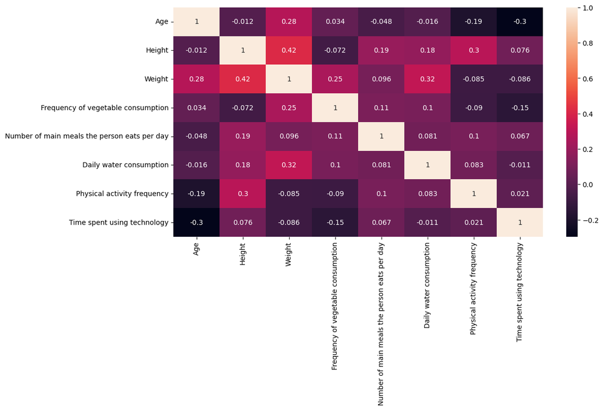

```python
figure(figsize=(12,	6))
heatmap(train_df.select_dtypes(include='number').corr(), annot=True)
show()
```

##### **Weight and Height (0.42)**: There is a moderate positive correlation, meaning that generally, taller people tend to weigh more.

##### **Weight and Age (0.28)**: There is a weak positive correlation, suggesting a slight tendency for weight to increase with age in dataset.

##### **Weight and Daily water consumption (0.32)**: There is a weak positive correlation, suggesting a slight tendency for individuals who consume more water to also weigh more in dataset.

##### **Height and Physical activity frequency (0.3)**: There is a weak positive correlation, suggesting a slight tendency for taller individuals to engage in physical activity more frequently.

##### **Age and Time spent using technology (-0.3)**: There is a weak negative correlation, suggesting a slight tendency for older individuals to spend less time using technology.

##### **Physical activity frequency and Time spent using technology (0.021)**: The correlation is very weak and almost zero, indicating almost no linear relationship between how frequently someone engages in physical activity and the time they spend using technology in dataset.

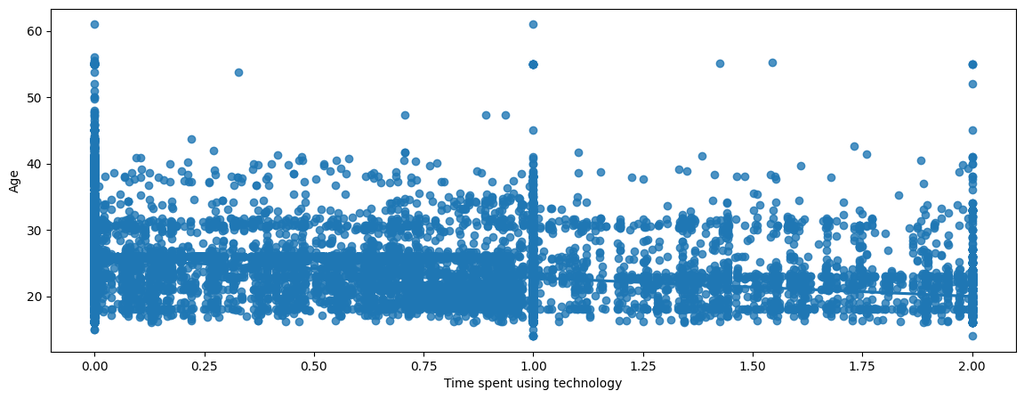

```python
fig,ax = subplots()
fig.set_size_inches(14, 5)
regplot(x="Time spent using technology", y="Age", data=train_df,ax=ax)
show()
```

## **Feature Extraction**

```python
train_df['Frequency of vegetable consumption'].value_counts()
```

```
Frequency of vegetable consumption
3.000000    7658
2.000000    7653
1.000000     275
2.967300     121
2.766612      54
            ...
2.443674       1
1.111887       1
1.595746       1
2.577427       1
2.731368       1
Name: count, Length: 934, dtype: int64
```

##### Transform values in column **Frequency of vegetable consumption** with **round()** function

```python
train_df['Frequency of vegetable consumption'] = train_df['Frequency of vegetable consumption'].apply(lambda x : round(x))
```

```python
train_df['Frequency of vegetable consumption'].value_counts()
```

```
Frequency of vegetable consumption
3    10092
2     9911
1      755
Name: count, dtype: int64
```

#### Extracting new column **[Frequency of vegetable consumption Classes]** from **[Frequency of vegetable consumption]**

```python
def fcvc(m):
    m = int(m)
    if m == 1:
        return 'Rarely consumes vegetables'
    if m == 2:
        return 'Sometimes consumes vegetables'
    if m == 3:
        return 'Regularly consumes vegetables'

train_df['Frequency of vegetable consumption Classes'] = train_df['Frequency of vegetable consumption'].apply(lambda x : fcvc(x))
```

```python
train_df['Frequency of vegetable consumption Classes'].value_counts()
```

```
Frequency of vegetable consumption Classes
Regularly consumes vegetables    10092
Sometimes consumes vegetables     9911
Rarely consumes vegetables         755
Name: count, dtype: int64
```

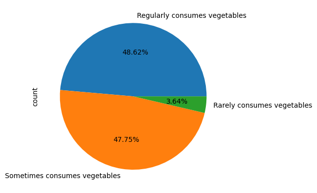

```python
train_df['Frequency of vegetable consumption Classes'].value_counts().plot.pie(autopct='%0.2f%%')
show()
```

##### **The percentage of rarely consumes vegetables is very low (3.64 %) compared to the rest of the other percentages**

```python
train_df['Number of main meals the person eats per day'].value_counts()
```

```
Number of main meals the person eats per day
3.000000    14706
1.000000     1976
4.000000      715
2.993623       39
2.695396       25
            ...
3.608850        1
1.193486        1
2.737620        1
3.019574        1
2.256119        1
Name: count, Length: 689, dtype: int64
```

##### Transform values in column **Number of main meals the person eats per day** with **round()** function

```python
train_df['Number of main meals the person eats per day'] = train_df['Number of main meals the person eats per day'].apply(lambda x : round(x))
```

```python
train_df['Number of main meals the person eats per day'] = train_df['Number of main meals the person eats per day'].astype(int)
```

```python
train_df['Number of main meals the person eats per day'].unique()
```

```
array([3, 1, 2, 4])
```

```python
train_df['Number of main meals the person eats per day'].value_counts()
```

```
Number of main meals the person eats per day
3    16309
1     2510
4     1040
2      899
Name: count, dtype: int64
```

#### Extracting new column **[Number of main meals the person eats per day Classes]** from **[Number of main meals the person eats per day]**

```python
def fncp(m):
    m = int(m)
    if m == 1:
        return 'One meal per day'
    if m == 2:
        return 'Two meals per day'
    if m == 3:
        return 'Three meals per day'
    if m == 4:
        return 'More than three meals'

train_df['Number of main meals the person eats per day Classes'] = train_df['Number of main meals the person eats per day'].apply(lambda x : fncp(x))
```

```python
train_df['Number of main meals the person eats per day Classes'].value_counts()
```

```
Number of main meals the person eats per day Classes
Three meals per day      16309
One meal per day          2510
More than three meals     1040
Two meals per day          899
Name: count, dtype: int64
```

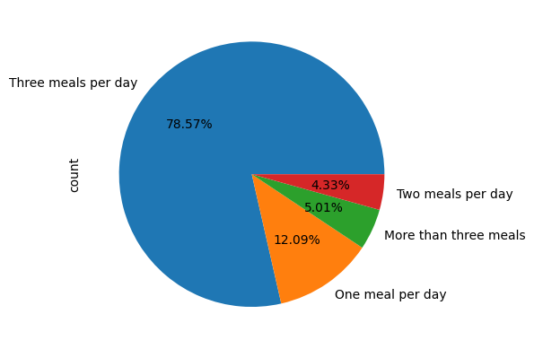

```python
train_df['Number of main meals the person eats per day Classes'].value_counts().plot.pie(autopct='%0.2f%%')
show()
```

##### **The percentage of eating three meals per day is very hight (78.57 %) compared to the rest of the other percentages**

#### Extracting new column **[Daily water consumption Classes]** from **[Daily water consumption]**

```python
train_df['Daily water consumption'].value_counts()
```

```
Daily water consumption
2.000000    6616
1.000000    2799
3.000000    1571
2.825629      77
2.868167      60
            ...
2.835195       1
2.632983       1
2.090213       1
2.756916       1
1.365188       1
Name: count, Length: 1506, dtype: int64
```

```python
def fncp(m):
    m = int(m)
    if m <= 1:
        return 'Low water intake'
    elif m <= 2:
        return 'Moderate water intake'
    if m > 2:
        return 'High water intake'

train_df['Daily water consumption Classes'] = train_df['Daily water consumption'].apply(lambda x : fncp(x))
```

```python
train_df['Daily water consumption Classes'].value_counts()
```

```
Daily water consumption Classes
Moderate water intake    13051
Low water intake          6136
High water intake         1571
Name: count, dtype: int64
```

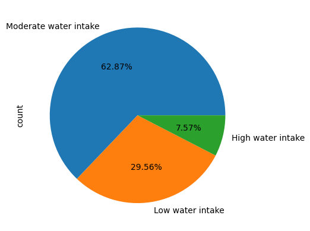

```python
train_df['Daily water consumption Classes'].value_counts().plot.pie(autopct='%0.2f%%')
show()
```

##### **The percentage of moderate water intake is very hight (62.87 %) compared to the rest of the other percentages**

#### Extracting new column **[Physical activity frequency Classes]** from **[Physical activity frequency]**

```python
train_df['Physical activity frequency'].value_counts()
```

```
Physical activity frequency
0.000000    5044
1.000000    4097
2.000000    2391
3.000000     800
1.097905      56
            ...
1.706287       1
0.675983       1
1.923607       1
1.320209       1
0.988668       1
Name: count, Length: 1360, dtype: int64
```

```python
def fncp(m):
    m = int(m)
    if m == 0 :
        return 'No physical activity'
    elif m <= 1 :
        return 'Very low activity'
    elif m < 2.6 :
        return 'Low to moderate activity'
    else :
        return 'Moderate activity'

train_df['Physical activity frequency Classes'] = train_df['Physical activity frequency'].apply(lambda x : fncp(x))
```

```python
train_df['Physical activity frequency Classes'].value_counts()
```

```
Physical activity frequency Classes
No physical activity        9191
Very low activity           7886
Low to moderate activity    2881
Moderate activity            800
Name: count, dtype: int64
```

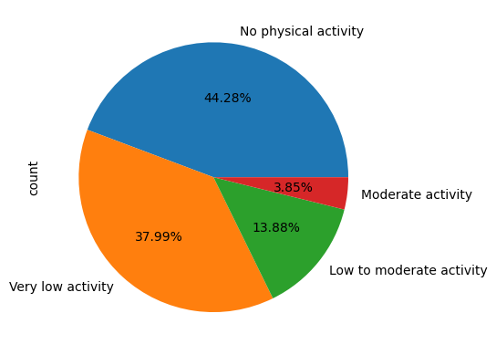

```python
train_df['Physical activity frequency Classes'].value_counts().plot.pie(autopct='%0.2f%%')
show()
```

##### **The percentage of moderate activity is very low (3.85 %) compared to the rest of the other percentages**

#### Extracting new column **[Time spent using technology Classes]** from **[Time spent using technology]**

```python
train_df['Time spent using technology'].value_counts()
```

```
Time spent using technology
0.000000    6566
1.000000    4326
2.000000    1133
0.002600      78
0.723154      65
            ...
1.223661       1
0.057868       1
0.236067       1
0.073088       1
0.768375       1
Name: count, Length: 1297, dtype: int64
```

```python
def fncp(m):
    m = int(m)
    if m <= 1 :
        return 'Very low screen time'
    else :
        return 'Moderate screen time'

train_df['Time spent using technology Classes'] = train_df['Time spent using technology'].apply(lambda x : fncp(x))
```

```python
train_df['Time spent using technology Classes'].value_counts()
```

```
Time spent using technology Classes
Very low screen time    19625
Moderate screen time     1133
Name: count, dtype: int64
```

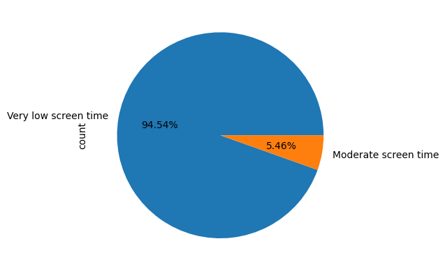

```python
train_df['Time spent using technology Classes'].value_counts().plot.pie(autopct='%0.2f%%')
show()
```

##### **The percentage of very low screen time is very hight (94.54 %) compared to the rest of the other percentages**

##### Transform values in column **Age** with **round()** function

```python
train_df['Age']
```

```
0        24.443011
1        18.000000
2        18.000000
3        20.952737
4        31.641081
           ...
20753    25.137087
20754    18.000000
20755    20.101026
20756    33.852953
20757    26.680376
Name: Age, Length: 20758, dtype: float64
```

```python
train_df['Age'] = train_df['Age'].apply(lambda x : int(round(x)))
train_df['Age']
```

```
0        24
1        18
2        18
3        21
4        32
         ..
20753    25
20754    18
20755    20
20756    34
20757    27
Name: Age, Length: 20758, dtype: int64
```

```python
# train_df.to_csv('Obesity risk (New data).csv',index=False)
```

## **Detect Outliers**

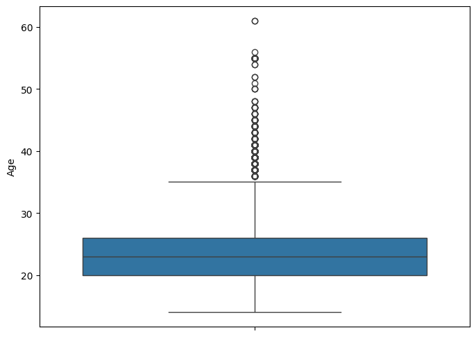

```python
fig, axes = subplots(nrows=1, ncols=1)
fig.set_size_inches(8, 6)
boxplot(data = train_df, y = 'Age', orient="v", ax=axes)
show()
```

##### The majority of individuals in dataset are between approximately 20 and 26 years old.

##### The median age is around 23 years old.

##### There are some younger individuals (down to around 14 years old) and a number of significantly older individuals (outliers) in the dataset.

```python
Q1=train_df['Age'].quantile(0.25)
Q3=train_df['Age'].quantile(0.75)
IQR = Q3-Q1

Lower_bound = Q1 - 1.5*IQR
Upper_bound = Q3 + 1.5*IQR

outliers = ((train_df['Age']>Upper_bound)|(train_df['Age']<Lower_bound)).sum()
Total = train_df['Age'].shape[0]
print(f'Total of outliers in Age are : {outliers}--{round(100*(outliers)/Total,2)}%')

if outliers > 0:
    train_df=train_df.loc[(train_df['Age'] <= Upper_bound) & (train_df['Age'] >= Lower_bound)]
```

```
Total of outliers in Age are : 1029--4.96%
```

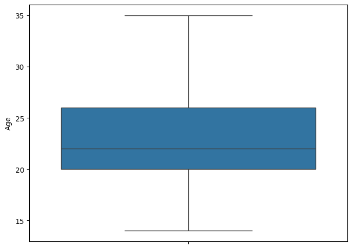

```python
fig, axes = subplots(nrows=1, ncols=1)
fig.set_size_inches(8, 6)
boxplot(data = train_df, y = 'Age', orient="v", ax=axes)
show()
```

##### The overall range of ages is now from approximately 14 to 35 years old.

```python
# train_df.to_csv('train data (New data).csv',index=False)
```

## **Analysis**

##### **Investigate relationships between Gender and Physical activity frequency Classes**

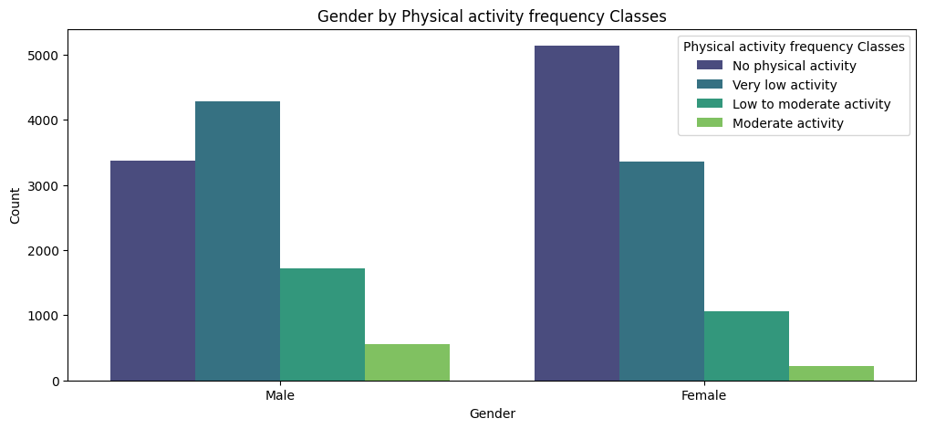

```python
figure(figsize=(12,	5))
countplot(data=train_df, x='Gender', hue='Physical activity frequency Classes',	palette='viridis')
title('Gender by Physical activity frequency Classes')
xlabel('Gender')
# plt.xticks(rotation=45)
ylabel('Count')
show()
```

##### There appears to be a gender disparity in physical activity levels. A higher proportion of females in this dataset report having no physical activity, while a higher proportion of males report engaging in very low to moderate activity.

### **Summary**:

##### Lack of physical activity is a significant characteristic for both males and females, but more so for females.

##### Males tend to have slightly higher engagement in very low to moderate physical activity compared to females.

##### Moderate physical activity is the least common across both genders.

##### This information could be crucial for understanding the lifestyle habits within study population and how they might relate to obesity risk.

##### **Investigate relationships between Gender and Obesity level class**

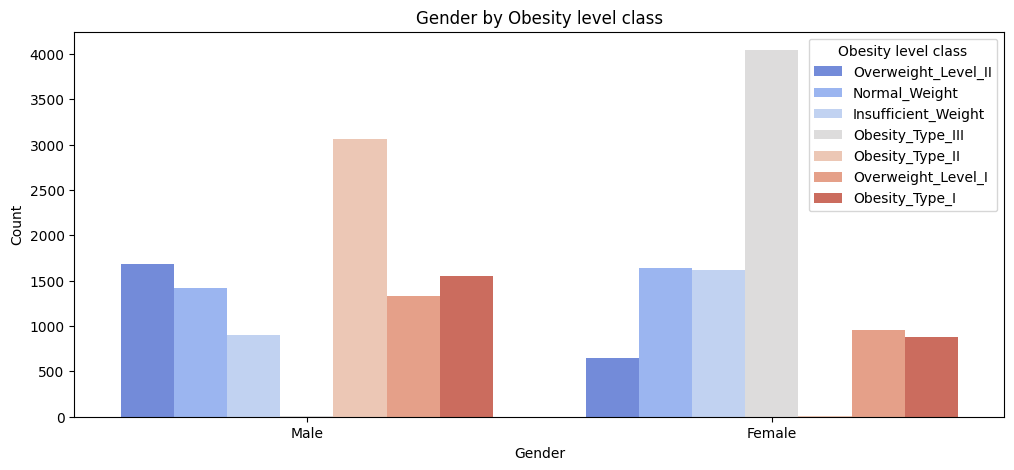

```python
figure(figsize=(12, 5))
countplot(data=train_df, x='Gender', hue='Obesity level class', palette='coolwarm')
title('Gender by Obesity level class')
xlabel('Gender')
ylabel('Count')
show()
```

##### **Normal Weight** and **Overweight_Level_II** are relatively common in both genders.

##### **Insufficient Weight** is more prevalent in females than males in this dataset.

##### **Obesity_Type_III** is significantly more common in females than males.

##### **Obesity_Type_II**, Overweight_Level_I, and Obesity_Type_I are more prevalent in males than females.

##### **Analyze weight distribution by Gender**

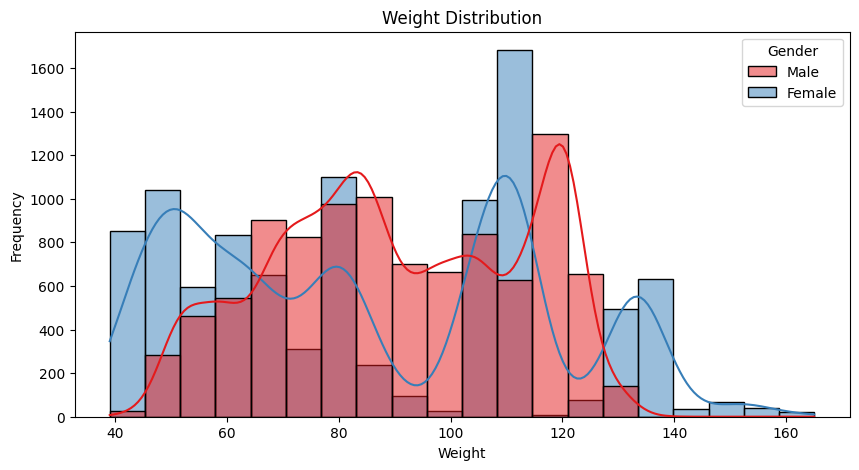

```python
figure(figsize=(10, 5))
histplot(data=train_df,	x='Weight',	hue='Gender', kde=True, bins=20, palette='Set1')
title('Weight Distribution')
xlabel('Weight')
ylabel('Frequency')
show()
```

### **Gender Comparison**:

##### **Analyze Height distribution by Gender**

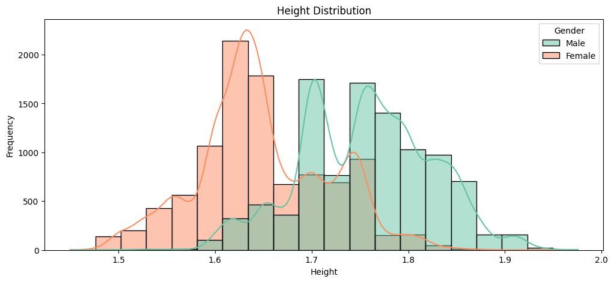

```python
figure(figsize=(12, 5))
histplot(data=train_df,	x='Height',	hue='Gender', kde=True, bins=20, palette='Set2')
title('Height Distribution')
xlabel('Height')
ylabel('Frequency')
show()
```

### **Gender Comparison**:

##### **Gender** with **Age > 30** and **Weight >= 90**

```python
GenderGt30AndWeightGte90 = train_df.loc[(train_df['Age'] > 30) & (train_df['Weight'] >= 90) , (['Age','Gender','Weight'])]
```

```python
GenderGt30AndWeightGte90
```

|  | Age | Gender | Weight |
| --- | --- | --- | --- |
| 4 | 32 | Male | 93.798055 |
| 46 | 31 | Male | 120.998266 |
| 102 | 31 | Male | 122.813033 |
| 103 | 32 | Male | 90.000000 |
| 203 | 35 | Female | 90.000000 |
| ... | ... | ... | ... |
| 20583 | 34 | Male | 91.059595 |
| 20598 | 31 | Male | 112.277567 |
| 20635 | 31 | Male | 120.919703 |
| 20710 | 34 | Male | 102.134646 |
| 20747 | 33 | Male | 99.000000 |

961 rows × 3 columns

```python
GenderGt30AndWeightGte90['Age'].value_counts()
```

```
Age
31    550
32    160
33    154
34     68
35     29
Name: count, dtype: int64
```

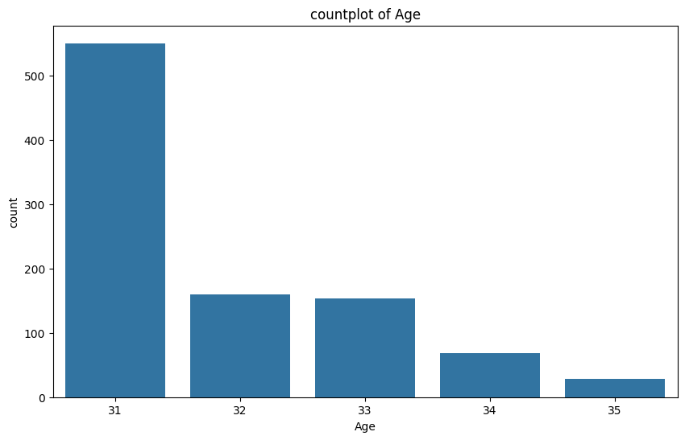

```python
figure(figsize=(10, 6))
countplot(data = GenderGt30AndWeightGte90, x = 'Age', order = GenderGt30AndWeightGte90['Age'].value_counts().index)
title('countplot of Age')
show()
```

```python
GenderGt30AndWeightGte90['Gender'].value_counts()
```

```
Gender
Male      955
Female      6
Name: count, dtype: int64
```

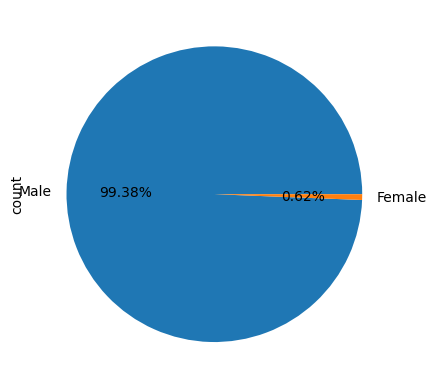

```python
GenderGt30AndWeightGte90['Gender'].value_counts().plot.pie(autopct='%0.2f%%')
show()
```

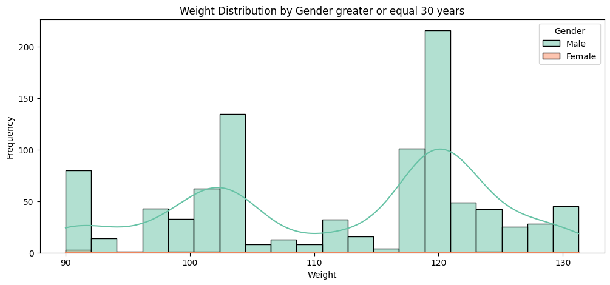

```python
figure(figsize=(12, 5))
histplot(data=GenderGt30AndWeightGte90,	x='Weight',	hue='Gender', kde=True, bins=20, palette='Set2')
title('Weight Distribution by Gender greater or equal 30 years')
xlabel('Weight')
ylabel('Frequency')
show()
```

### **Gender Comparison within this Weight Range**:

##### **Higher Prevalence of Males**: Males are significantly more represented in the weight range of 90 kg to 130 kg compared to females in dataset.

##### **Different Distribution Shapes**: While males show a bimodal distribution within this range, the number of females is too low to discern a clear distribution pattern.

### **This zoomed-in view of the higher weight range suggests that**:

##### Weights between 90 kg and 130 kg are considerably more common among males in dataset.

##### Within this higher weight segment for males, there are two likely subgroups with average weights around 103 kg and 121 kg.

##### Females are relatively rare in this higher weight range within dataset.

##### **Gender** with **Age <= 30** and **Weight >= 90**

```python
GenderLte30AndWeightGte90 = train_df.loc[(train_df['Age'] <= 30) & (train_df['Weight'] >= 90) , (['Age','Gender','Weight'])]
```

```python
GenderLte30AndWeightGte90['Age'].value_counts()
```

```
Age
26    2860
23     849
21     833
22     630
25     517
24     505
18     454
27     303
30     291
19     215
20     202
28     144
29     116
17      66
16       1
Name: count, dtype: int64
```

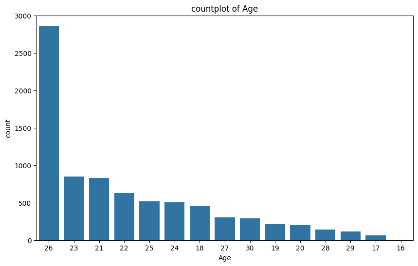

```python
figure(figsize=(10, 6))
countplot(data = GenderLte30AndWeightGte90, x = 'Age', order = GenderLte30AndWeightGte90['Age'].value_counts().index)
title('countplot of Age')
show()
```

```python
GenderLte30AndWeightGte90['Gender'].value_counts()
```

```
Gender
Female    4151
Male      3835
Name: count, dtype: int64
```

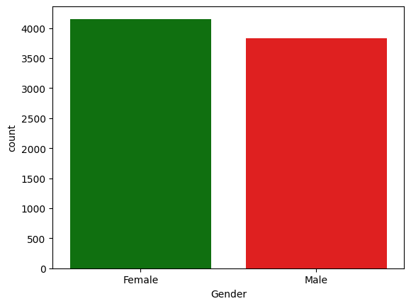

```python
countplot(x='Gender', data=GenderLte30AndWeightGte90, palette=['green','red'])
xlabel('Gender')
show()
```

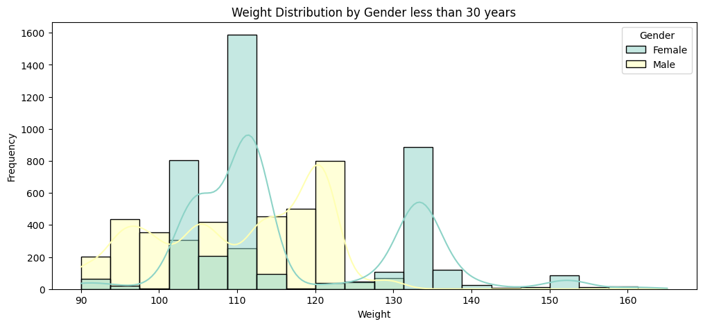

```python
figure(figsize=(12, 5))
histplot(data=GenderLte30AndWeightGte90,	x='Weight',	hue='Gender', kde=True, bins=20, palette='Set3')
title('Weight Distribution by Gender less than 30 years')
xlabel('Weight')
ylabel('Frequency')
show()
```

### **Gender Comparison within this Weight Range**:

##### **Different Primary Peaks**: Females in this higher weight segment tend to cluster more around 110-112 kg, while males tend to cluster more around 120-122 kg.

##### **Secondary Peak Difference**: Males show a secondary cluster at a lower weight range (95-98 kg) within this selection, whereas the secondary cluster for females is at a higher weight range (135-138 kg).

##### **Overlap**: There is an overlap in the weight distributions, particularly between 100 kg and 130 kg, where both genders have significant representation.

##### **Tail Distribution**: The distribution tails off at the higher end for both genders, indicating fewer individuals with very high weights.